# Risk Factor Analysis

## Outcome Variable

**Outcome Variable:** dead

## Predictor Variables

**Intervention Variable:** ever_stunted06

**Adjustment Set:**

- sex
- arm
- brthmon
- vagbrth
- impfloor
- hhwealth_quart
- W_mage
- W_mhtcm
- W_mwtkg
- W_mbmi
- W_meducyrs
- W_feducyrs
- W_nrooms
- W_nchldlt5
- W_parity
- impsan
- safeh20
- delta_vagbrth
- delta_impfloor
- delta_hhwealth_quart
- delta_W_mage
- delta_W_mhtcm
- delta_W_mwtkg
- delta_W_mbmi
- delta_W_meducyrs
- delta_W_feducyrs
- delta_W_nrooms
- delta_W_nchldlt5
- delta_W_parity
- delta_impsan
- delta_safeh20

## Stratifying Variables

The analysis was stratified on these variable(s):

- studyid
- country

## Data Summary

| studyid | country | ever_stunted06 | dead | n_cell | n | outcome_variable |
| --- | --- | --- | --- | --- | --- | --- |
| EE | PAKISTAN | 0 | 0 | 93 | 379 | dead |
| EE | PAKISTAN | 0 | 1 | 0 | 379 | dead |
| EE | PAKISTAN | 1 | 0 | 282 | 379 | dead |
| EE | PAKISTAN | 1 | 1 | 4 | 379 | dead |
| GMS-Nepal | NEPAL | 0 | 0 | 472 | 697 | dead |
| GMS-Nepal | NEPAL | 0 | 1 | 3 | 697 | dead |
| GMS-Nepal | NEPAL | 1 | 0 | 217 | 697 | dead |
| GMS-Nepal | NEPAL | 1 | 1 | 5 | 697 | dead |
| iLiNS-DYAD-M | MALAWI | 0 | 0 | 753 | 1063 | dead |
| iLiNS-DYAD-M | MALAWI | 0 | 1 | 20 | 1063 | dead |
| iLiNS-DYAD-M | MALAWI | 1 | 0 | 278 | 1063 | dead |
| iLiNS-DYAD-M | MALAWI | 1 | 1 | 12 | 1063 | dead |
| JiVitA-3 | BANGLADESH | 0 | 0 | 13668 | 24995 | dead |
| JiVitA-3 | BANGLADESH | 0 | 1 | 247 | 24995 | dead |
| JiVitA-3 | BANGLADESH | 1 | 0 | 10564 | 24995 | dead |
| JiVitA-3 | BANGLADESH | 1 | 1 | 516 | 24995 | dead |
| JiVitA-4 | BANGLADESH | 0 | 0 | 2236 | 3788 | dead |
| JiVitA-4 | BANGLADESH | 0 | 1 | 14 | 3788 | dead |
| JiVitA-4 | BANGLADESH | 1 | 0 | 1523 | 3788 | dead |
| JiVitA-4 | BANGLADESH | 1 | 1 | 15 | 3788 | dead |
| Keneba | GAMBIA | 0 | 0 | 1228 | 1833 | dead |
| Keneba | GAMBIA | 0 | 1 | 19 | 1833 | dead |
| Keneba | GAMBIA | 1 | 0 | 562 | 1833 | dead |
| Keneba | GAMBIA | 1 | 1 | 24 | 1833 | dead |
| MAL-ED | BANGLADESH | 0 | 0 | 167 | 265 | dead |
| MAL-ED | BANGLADESH | 0 | 1 | 0 | 265 | dead |
| MAL-ED | BANGLADESH | 1 | 0 | 95 | 265 | dead |
| MAL-ED | BANGLADESH | 1 | 1 | 3 | 265 | dead |
| MAL-ED | INDIA | 0 | 0 | 158 | 251 | dead |
| MAL-ED | INDIA | 0 | 1 | 1 | 251 | dead |
| MAL-ED | INDIA | 1 | 0 | 91 | 251 | dead |
| MAL-ED | INDIA | 1 | 1 | 1 | 251 | dead |
| MAL-ED | PERU | 0 | 0 | 171 | 303 | dead |
| MAL-ED | PERU | 0 | 1 | 1 | 303 | dead |
| MAL-ED | PERU | 1 | 0 | 130 | 303 | dead |
| MAL-ED | PERU | 1 | 1 | 1 | 303 | dead |
| MAL-ED | SOUTH AFRICA | 0 | 0 | 194 | 314 | dead |
| MAL-ED | SOUTH AFRICA | 0 | 1 | 0 | 314 | dead |
| MAL-ED | SOUTH AFRICA | 1 | 0 | 119 | 314 | dead |
| MAL-ED | SOUTH AFRICA | 1 | 1 | 1 | 314 | dead |
| MAL-ED | TANZANIA, UNITED REPUBLIC OF | 0 | 0 | 148 | 262 | dead |
| MAL-ED | TANZANIA, UNITED REPUBLIC OF | 0 | 1 | 1 | 262 | dead |
| MAL-ED | TANZANIA, UNITED REPUBLIC OF | 1 | 0 | 111 | 262 | dead |
| MAL-ED | TANZANIA, UNITED REPUBLIC OF | 1 | 1 | 2 | 262 | dead |
| PROVIDE | BANGLADESH | 0 | 0 | 527 | 700 | dead |
| PROVIDE | BANGLADESH | 0 | 1 | 4 | 700 | dead |
| PROVIDE | BANGLADESH | 1 | 0 | 169 | 700 | dead |
| PROVIDE | BANGLADESH | 1 | 1 | 0 | 700 | dead |
| SAS-CompFeed | INDIA | 0 | 0 | 823 | 1474 | dead |
| SAS-CompFeed | INDIA | 0 | 1 | 14 | 1474 | dead |
| SAS-CompFeed | INDIA | 1 | 0 | 602 | 1474 | dead |
| SAS-CompFeed | INDIA | 1 | 1 | 35 | 1474 | dead |
| TanzaniaChild2 | TANZANIA, UNITED REPUBLIC OF | 0 | 0 | 1 | 1 | dead |
| TanzaniaChild2 | TANZANIA, UNITED REPUBLIC OF | 0 | 1 | 0 | 1 | dead |
| TanzaniaChild2 | TANZANIA, UNITED REPUBLIC OF | 1 | 0 | 0 | 1 | dead |
| TanzaniaChild2 | TANZANIA, UNITED REPUBLIC OF | 1 | 1 | 0 | 1 | dead |
| ZVITAMBO | ZIMBABWE | 0 | 0 | 9301 | 13875 | dead |
| ZVITAMBO | ZIMBABWE | 0 | 1 | 619 | 13875 | dead |
| ZVITAMBO | ZIMBABWE | 1 | 0 | 3477 | 13875 | dead |
| ZVITAMBO | ZIMBABWE | 1 | 1 | 478 | 13875 | dead |

The following strata were considered:

- studyid: EE, country: PAKISTAN
- studyid: GMS-Nepal, country: NEPAL
- studyid: iLiNS-DYAD-M, country: MALAWI
- studyid: JiVitA-3, country: BANGLADESH
- studyid: JiVitA-4, country: BANGLADESH
- studyid: Keneba, country: GAMBIA
- studyid: MAL-ED, country: BANGLADESH
- studyid: MAL-ED, country: INDIA
- studyid: MAL-ED, country: PERU
- studyid: MAL-ED, country: SOUTH AFRICA
- studyid: MAL-ED, country: TANZANIA, UNITED REPUBLIC OF
- studyid: PROVIDE, country: BANGLADESH
- studyid: SAS-CompFeed, country: INDIA
- studyid: TanzaniaChild2, country: TANZANIA, UNITED REPUBLIC OF
- studyid: ZVITAMBO, country: ZIMBABWE

### Dropped Strata

Some strata were dropped due to rare outcomes:

- studyid: EE, country: PAKISTAN
- studyid: GMS-Nepal, country: NEPAL
- studyid: MAL-ED, country: BANGLADESH
- studyid: MAL-ED, country: INDIA
- studyid: MAL-ED, country: PERU
- studyid: MAL-ED, country: SOUTH AFRICA
- studyid: MAL-ED, country: TANZANIA, UNITED REPUBLIC OF
- studyid: PROVIDE, country: BANGLADESH
- studyid: TanzaniaChild2, country: TANZANIA, UNITED REPUBLIC OF

## Methods Detail

We’re interested in the causal parameters $E[Y_a]$ for all values of $a \in \mathcal{A}$. These parameters represent the mean outcome if, possibly contrary to fact, we intervened to set all units to have $A=a$. Under the randomization and positivity assumptions, these are identified by the statistical parameters $\psi_a=E_W[E_{Y|A,W}(Y|A=a,W)]$. In addition, we’re interested in the mean of $Y$, $E[Y]$ under no intervention (the observed mean). We will estimate these parameters by using SuperLearner to fit the relevant likelihood factors – $E_{Y|A,W}(Y|A=a,W)$ and $p(A=a|W)$, and then updating our likelihood fit using a joint TMLE.

For unadjusted analyses ($W=\{\}$), initial likelihoods were estimated using Lrnr_glm to estimate the simple $E(Y|A)$ and Lrnr_mean to estimate $p(A)$. For adjusted analyses, a small library containing Lrnr_glmnet, Lrnr_xgboost, and Lrnr_mean was used.

Having estimated these parameters, we will then use the delta method to estimate relative risks and attributable risks relative to a prespecified baseline level of $A$.

# Results Detail

## Results Plots

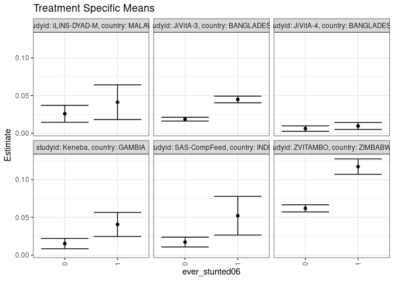

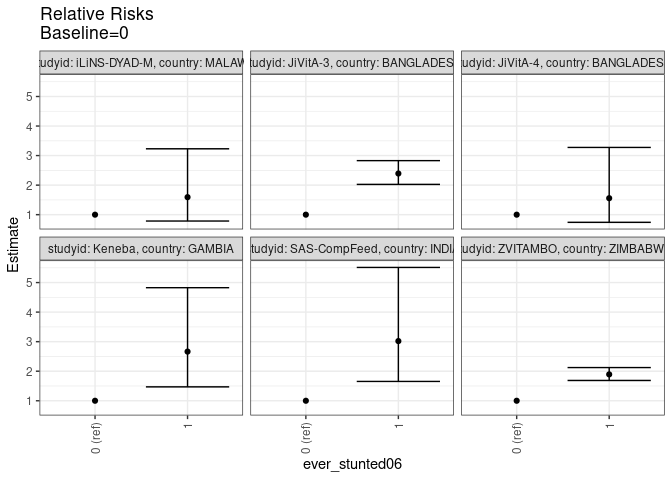

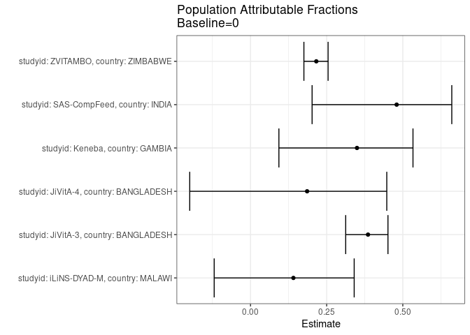

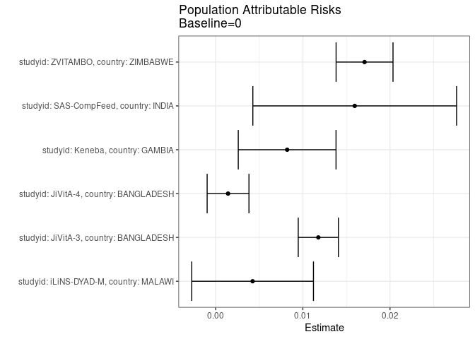

## Results Table

### Parameter: TSM

| studyid | country | intervention_level | baseline_level | estimate | ci_lower | ci_upper |
| --- | --- | --- | --- | --- | --- | --- |
| iLiNS-DYAD-M | MALAWI | 0 | NA | 0.0258655 | 0.0146592 | 0.0370718 |
| iLiNS-DYAD-M | MALAWI | 1 | NA | 0.0411907 | 0.0181862 | 0.0641951 |
| JiVitA-3 | BANGLADESH | 0 | NA | 0.0187493 | 0.0162587 | 0.0212400 |
| JiVitA-3 | BANGLADESH | 1 | NA | 0.0448702 | 0.0404897 | 0.0492506 |
| JiVitA-4 | BANGLADESH | 0 | NA | 0.0062332 | 0.0026248 | 0.0098415 |
| JiVitA-4 | BANGLADESH | 1 | NA | 0.0097082 | 0.0050684 | 0.0143480 |
| Keneba | GAMBIA | 0 | NA | 0.0152589 | 0.0084555 | 0.0220624 |
| Keneba | GAMBIA | 1 | NA | 0.0406474 | 0.0246794 | 0.0566154 |
| SAS-CompFeed | INDIA | 0 | NA | 0.0172924 | 0.0108413 | 0.0237436 |
| SAS-CompFeed | INDIA | 1 | NA | 0.0522199 | 0.0265911 | 0.0778487 |
| ZVITAMBO | ZIMBABWE | 0 | NA | 0.0619844 | 0.0572184 | 0.0667504 |
| ZVITAMBO | ZIMBABWE | 1 | NA | 0.1173086 | 0.1071126 | 0.1275045 |

### Parameter: E(Y)

| studyid | country | intervention_level | baseline_level | estimate | ci_lower | ci_upper |
| --- | --- | --- | --- | --- | --- | --- |
| iLiNS-DYAD-M | MALAWI | NA | NA | 0.0301035 | 0.0198267 | 0.0403803 |
| JiVitA-3 | BANGLADESH | NA | NA | 0.0305261 | 0.0282868 | 0.0327654 |
| JiVitA-4 | BANGLADESH | NA | NA | 0.0076558 | 0.0047643 | 0.0105472 |
| Keneba | GAMBIA | NA | NA | 0.0234588 | 0.0165280 | 0.0303896 |
| SAS-CompFeed | INDIA | NA | NA | 0.0332429 | 0.0211843 | 0.0453014 |
| ZVITAMBO | ZIMBABWE | NA | NA | 0.0790631 | 0.0745730 | 0.0835531 |

### Parameter: RR

| studyid | country | intervention_level | baseline_level | estimate | ci_lower | ci_upper |
| --- | --- | --- | --- | --- | --- | --- |
| iLiNS-DYAD-M | MALAWI | 0 | 0 | 1.000000 | 1.0000000 | 1.000000 |
| iLiNS-DYAD-M | MALAWI | 1 | 0 | 1.592494 | 0.7852312 | 3.229671 |
| JiVitA-3 | BANGLADESH | 0 | 0 | 1.000000 | 1.0000000 | 1.000000 |
| JiVitA-3 | BANGLADESH | 1 | 0 | 2.393162 | 2.0245596 | 2.828874 |
| JiVitA-4 | BANGLADESH | 0 | 0 | 1.000000 | 1.0000000 | 1.000000 |
| JiVitA-4 | BANGLADESH | 1 | 0 | 1.557511 | 0.7406201 | 3.275421 |
| Keneba | GAMBIA | 0 | 0 | 1.000000 | 1.0000000 | 1.000000 |
| Keneba | GAMBIA | 1 | 0 | 2.663842 | 1.4702704 | 4.826359 |
| SAS-CompFeed | INDIA | 0 | 0 | 1.000000 | 1.0000000 | 1.000000 |
| SAS-CompFeed | INDIA | 1 | 0 | 3.019813 | 1.6543273 | 5.512372 |
| ZVITAMBO | ZIMBABWE | 0 | 0 | 1.000000 | 1.0000000 | 1.000000 |
| ZVITAMBO | ZIMBABWE | 1 | 0 | 1.892550 | 1.6866208 | 2.123622 |

### Parameter: PAR

| studyid | country | intervention_level | baseline_level | estimate | ci_lower | ci_upper |
| --- | --- | --- | --- | --- | --- | --- |
| iLiNS-DYAD-M | MALAWI | 0 | NA | 0.0042380 | -0.0027418 | 0.0112177 |
| JiVitA-3 | BANGLADESH | 0 | NA | 0.0117768 | 0.0094725 | 0.0140811 |
| JiVitA-4 | BANGLADESH | 0 | NA | 0.0014226 | -0.0009750 | 0.0038202 |
| Keneba | GAMBIA | 0 | NA | 0.0081999 | 0.0025932 | 0.0138065 |
| SAS-CompFeed | INDIA | 0 | NA | 0.0159504 | 0.0042665 | 0.0276344 |
| ZVITAMBO | ZIMBABWE | 0 | NA | 0.0170787 | 0.0138151 | 0.0203423 |

### Parameter: PAF

| studyid | country | intervention_level | baseline_level | estimate | ci_lower | ci_upper |
| --- | --- | --- | --- | --- | --- | --- |
| iLiNS-DYAD-M | MALAWI | 0 | NA | 0.1407806 | -0.1192396 | 0.3403932 |
| JiVitA-3 | BANGLADESH | 0 | NA | 0.3857939 | 0.3125101 | 0.4512660 |
| JiVitA-4 | BANGLADESH | 0 | NA | 0.1858206 | -0.1995682 | 0.4473944 |
| Keneba | GAMBIA | 0 | NA | 0.3495434 | 0.0931878 | 0.5334273 |
| SAS-CompFeed | INDIA | 0 | NA | 0.4798155 | 0.2022181 | 0.6608197 |
| ZVITAMBO | ZIMBABWE | 0 | NA | 0.2160131 | 0.1753105 | 0.2547068 |